# Homework Chapter 1

Author

SOLUTIONS

## Instructions

This Homework comes from Chapter 1 of the Textbook. You should refer to AE_CH1 for some template code.

Complete the following exercises:

- E.1
- E.2
- E.3
- E.4
- E.10
- E.11
- E.13
- E.14

```r
library(tidyverse)
library(janitor)
library(infer)
library(broom)
```

## E.1

> Yes, we need all 20 mice to come from the same population. Otherwise observed differences in worm counts could be due to differences in populations. Different populations might respond differently to the worms and/or the treatment.

## E.2

> No, there could be confounding variables that could invalidate the causal relationship between treatment and worm count if mice are not randomly assigned. For example, perhaps the first 5 mice were less healthy and therefore slower and easier to catch.

## E.3

> No, causation cannot be inferred because there are many confounding variables that could be at play in causing the obesity, and random assignment was not used to rule out those confounding variables. For example, children may watch more TV because they aren’t involved in sports and have more free time, and the lack of physical activity is what causes the obesity.

## E.4

> A random sample is a sample where each person (or other observational unit) is chosen randomly from a population. A randomized experiment is where randomization is used to split observational units into treatment groups.

## E.10

> A p-value of 0.85 is greater than a significance level of *α* = 0.05, so the difference in group means is not significant. However, we cannot claim that there is no difference (can’t conclude the null hypothesis). It’s possible there is a true difference that could not be detected due to small sample size.

## E.11

```r
mice <- read_csv("./data/C1 Mice.csv") %>%
  clean_names()
```

### Part a

*Modify the code from the Q7 - Q9 section of AE-CH1*

```r
#compute difference observed in sample
diff_sample <- median(mice$female_trt) - median(mice$female_ctl)
diff_sample
```

```
[1] -8
```

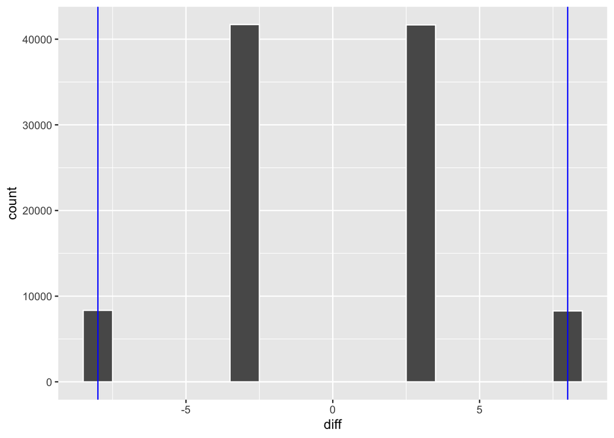

```r
mice_long <- mice %>%
  pivot_longer(cols = 1:4,
               names_to = "group",
               values_to = "worm_count")

mice_long <- mice_long %>%
  separate_wider_delim(group,
                       delim = "_",
                       names = c("sex", "group"))

#create subset for female mice only
females <- mice_long %>%
  filter(sex == "female") %>%
  select(worm_count)

diff <- c(1e5)
for(i in 1:100000){
  allocation <- sample(females$worm_count, size = 10)
  median_trt <- median(allocation[1:5])
  median_ctl <- median(allocation[6:10])
  diff[i] <- median_ctl - median_trt
}


#plot histogram of differences in medians (ctl - trt)
#add vertical line at observed difference in medians
sims <- data.frame(diff = diff)
ggplot(sims, aes(x = diff)) +
  geom_histogram(color = "white",
                 binwidth = 1) +
  geom_vline(xintercept = diff_sample,
             color = "blue") +
  geom_vline(xintercept = -diff_sample,
             color = "blue")
```

```r
#find the two-sided empirical p-value
p_value2 <- sum(diff > abs(diff_sample) |
                  diff < -abs(diff_sample))/100000
p_value2
```

```
[1] 0
```